# El pico está cerca en la Provincia de Buenos Aires

Daniel Gervini

1 de septiembre de 2020

El crecimiento exponencial es un fenómeno que asusta y confunde, porque estamos acostumbrados a mirar los números en forma absoluta y no relativa. Así, un aumento de 50 a 55 parece “poco” y un aumento de 2.000 a 2.100 parece “mucho”, cuando en realidad es al revés: lo primero es un aumento del 10% y lo segundo es del 5%. Esto está ocurriendo ahora en Buenos Aires y el conurbano, donde la gente está alarmada por las altas cifras diarias que, en realidad, están mostrando una evidente desaceleración.

Otro problema es que los informes de casos y muertes diarios están sujetos a variaciones aleatorias, por lo que para ver bien la tendencia hay que usar métodos de suavizado de datos que eliminen estas variaciones.

# La situación en Provincia

Los gráficos siguentes muestran la evolución de casos diarios confirmados y muertes en Provincia de Buenos Aires. Los círculos son los datos y la línea roja es la curva de suavizado. En la curva de casos diarios confirmados ya se ve una muy clara desaceleración y una tendencia al amesetamiento (no así en la de muertes, todavía). Todo parece indicar que el pico de casos diarios va a llegar dentro de los próximos 10 días, como habíamos previsto en [este post](https://dgervini.github.io/Coronavirus/Inmunidad_de_Rebanio.html) hace casi un mes.

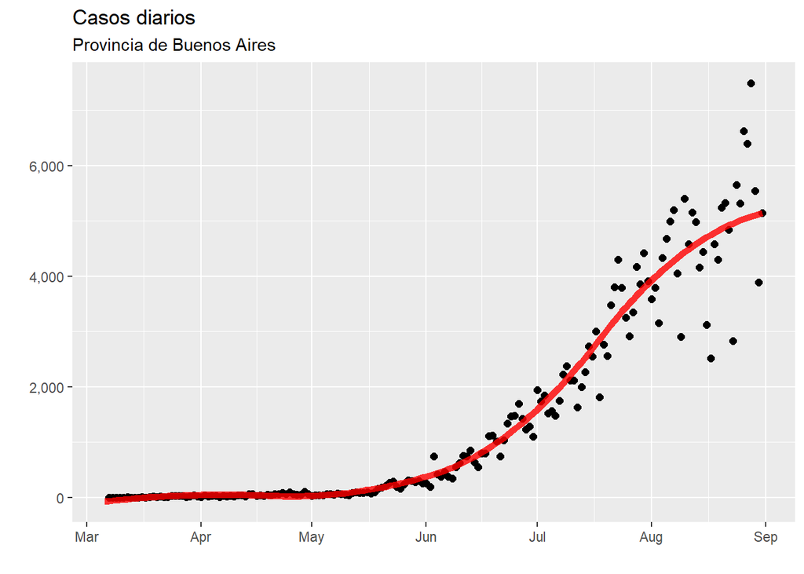

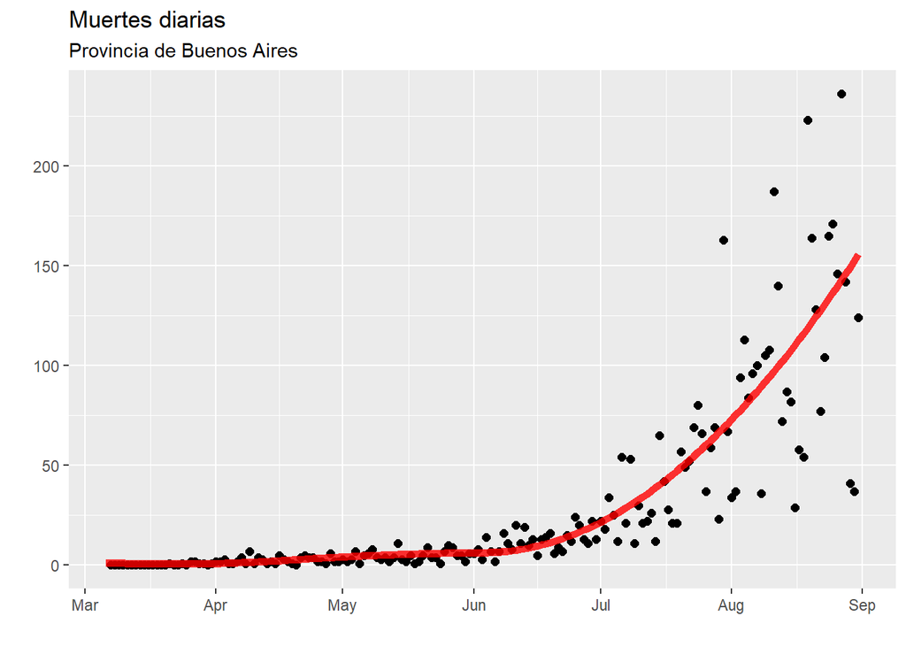

## La situación en la Ciudad

La curva de casos diarios en la ciudad de Buenos Aires está amesetada desde principios de agosto, como ya habíamos visto en [este post](https://dgervini.github.io/Coronavirus/Chequeando_predicciones.html) hace diez días. La novedad ahora es que la curva de muertes diarias también se amesetó. Esto es importante porque confirma el amesetamiento; los casos confirmados por tests siempre subestiman la cantidad real de contagiados, pero los muertos están generalmente bien contados.

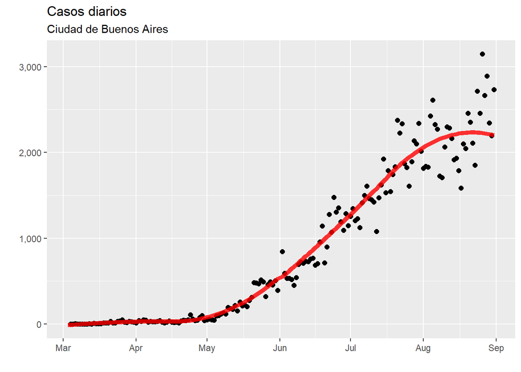

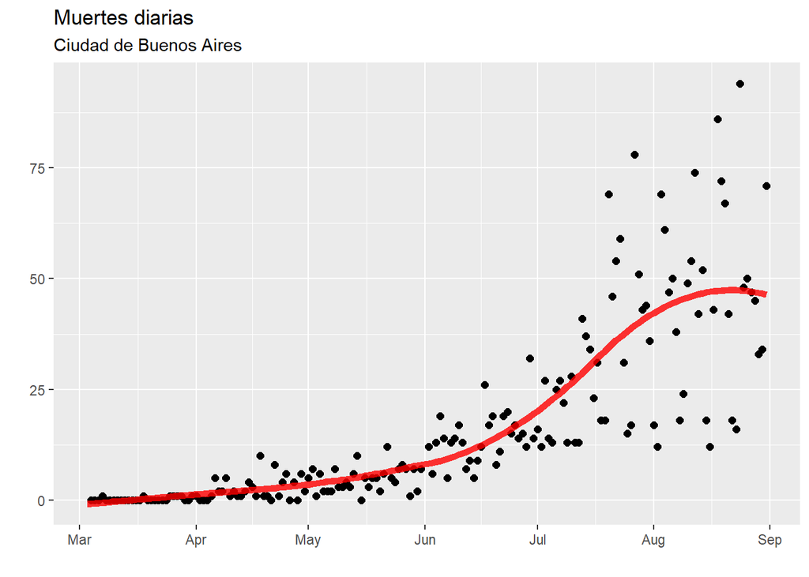

## ¿Qué es el pico?

Parece haber alguna confusión entre la gente sobre lo que es “el pico”. Muchos creen que el pico es el fin de la epidemia. En realidad, el pico es el **máximo de casos diarios**, pero después del pico los casos diarios empiezan a *descender lentamente* o incluso se amesetan por un tiempo, como en la ciudad de Buenos Aires. Por eso, el pico es **el medio** de la epidemia, no el final. Después del pico hay más o menos la misma cantidad de casos que antes del pico. Por eso, si el pico en el conurbano ocurre cuando haya 400.000 casos como estamos previendo, para el final de la pandemia a fines de Noviembre va a haber un total de 800.000 casos acumulados. Si a esto sumamos los aproximadamente 200.000 casos previstos para la Capital, para fines de Noviembre va a haber aproximadamente 1.000.000 de casos acumulados en el área metropolitana de Buenos Aires, que a la tasa de mortalidad actual del 2% significarían 20.000 muertos.

[Back to blog](https://sites.uwm.edu/gervini/coronavirus-blog/)